# Speech CogED Online

JC

1/08/2021

# Online Cog-ED Speech Pilots (30 YAs; ages 20-40)

```r
rm(list=ls())

# Packages
library(lme4); library(knitr); library(kableExtra); library(RColorBrewer); library(tidyverse);
source("summarySEwithin2.R")

#Create data directories
coged.path<-"~/Box Sync/CCPLab_Aging_Studies/Multi-Domain-Discounting/Data/Online/Pilots/coged_speech_0108.csv"
PTQ.path <- "~/Box Sync/CCPLab_Aging_Studies/Multi-Domain-Discounting/Data/Online/Pilots/speech_coged_ptq__0108.csv"

#Make data frames for Cog-ED and demographics info
coged<- read.csv(coged.path, header = T)
PTQ <- read.csv(PTQ.path, header = T)
```

```r
#clean data frame with Cog-ED SV estimates and transform data across so that SV estimates are equivalent across both domains (i.e., gain, loss)
d.coged <- coged %>% select(subjectid, groupid, IP12_1, IP12_2, IP12_3, IP13_1, IP13_2, IP13_3, IP14_1, IP14_2, IP14_3,
                            percentCorrect_N1, percentCorrect_N2, percentCorrect_N3, percentCorrect_N4) %>%
  group_by(subjectid) %>%
  mutate(SV_red = (IP12_1/2 + IP12_2/3 + IP12_3/4)/3,
         SV_blue = (IP13_1/2 + IP13_2/3 + IP13_3/4)/3,
         SV_purple = (IP14_1/2 + IP14_2/3 + IP14_3/4)/3)

d.coged.SV <- d.coged %>% select(subjectid, SV_red, SV_blue, SV_purple) %>%
  pivot_longer(names_to = "tmp", values_to = "SV", -c(subjectid)) %>%
  separate(col = tmp, into=c(NA,"Task"), sep = "_") %>%
  mutate(taskCode = factor(Task, levels=c("red","blue","purple"), labels=c(-1,0,1)))
d.coged.SV$taskCode <- as.numeric(d.coged.SV$taskCode)
```

## Cognitive Effort Discounting

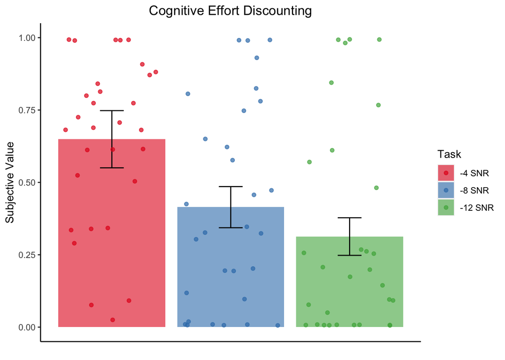

```r
CogED_sum <- summarySEwithin2(d.coged.SV, measurevar = "SV", withinvars = c("Task"), idvar = "subjectid")
CogED_sum$Task <- factor(CogED_sum$Task, levels = c("red","blue","purple"), labels = c("-4 SNR","-8 SNR","-12 SNR"))

d.coged.SV$Task <- factor(d.coged.SV$Task, levels = c("red","blue","purple"), labels = c("-4 SNR","-8 SNR","-12 SNR"))
#Plotting SV across both gain and loss domains
p.1 <- ggplot(CogED_sum, aes(x=Task, y=SV, fill=Task)) +
  theme(plot.title = element_text(hjust = 0.5), panel.grid.major = element_blank(), panel.grid.minor = element_blank(), panel.background = element_blank(), axis.line = element_line(colour = "black")) +
  geom_bar(stat="identity", position=position_dodge(), alpha = .6) +
  geom_errorbar(position=position_dodge(width=0.9), aes(ymin=SV-ci, ymax=SV+ci), width=.2) +
  geom_point(data = d.coged.SV, aes(x=Task, y=SV, color=Task),
             stat="identity", alpha=0.7, position = "jitter") +
  coord_cartesian(ylim=c(0,1)) +
  scale_x_discrete(breaks=NULL) +
  xlab("") + ylab("Subjective Value") + ggtitle("Cognitive Effort Discounting")
p.1 + scale_fill_brewer(palette = "Set1") + scale_color_brewer(palette = "Set1")
```

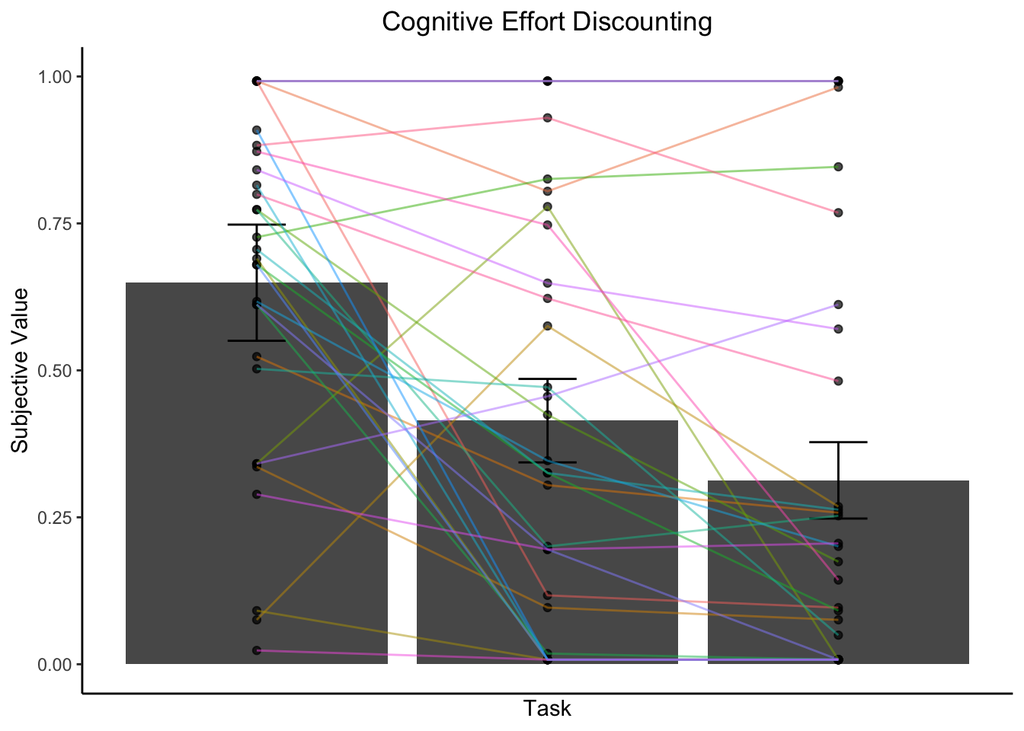

```r
p.2 <- ggplot(CogED_sum, aes(x=Task, y=SV)) +
  theme(plot.title = element_text(hjust = 0.5), panel.grid.major = element_blank(), panel.grid.minor = element_blank(), panel.background = element_blank(), axis.line = element_line(colour = "black")) +
  geom_bar(stat="identity", position=position_dodge()) +
  geom_errorbar(position=position_dodge(width=0.9), aes(ymin=SV-ci, ymax=SV+ci), width=.2) +
  geom_point(data = d.coged.SV, aes(x=Task, y=SV, group=subjectid),
             stat="identity", alpha=0.7) +
  geom_line(data = d.coged.SV, aes(x=Task, y=SV, group=subjectid, colour = factor(subjectid)), alpha = .5) +
  coord_cartesian(ylim=c(0,1)) +
  scale_x_discrete(breaks=NULL) +
  xlab("Task") + ylab("Subjective Value") + ggtitle("Cognitive Effort Discounting")
p.CogED <- p.2 + guides(colour=FALSE)
p.CogED
```

## NASA TLX

#### Participants completed NASA ratings after each load level during the familiarization phase (likert scale: 1-21; higher values indicate greater endorsement)

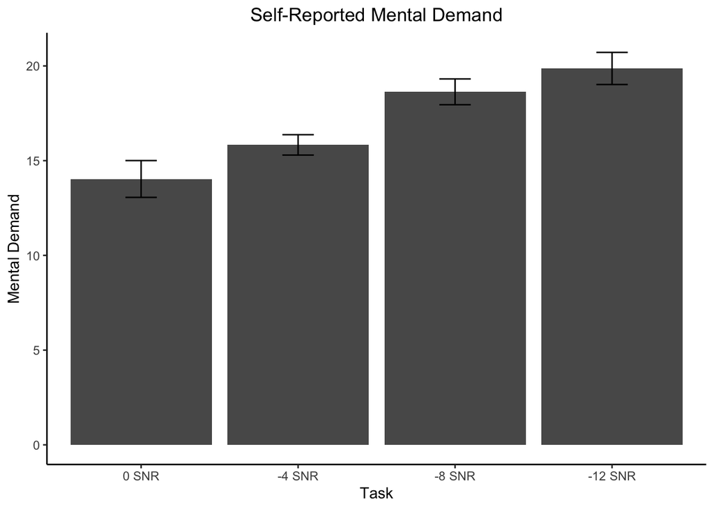

```r
#Mental Demand Ratings
NASA.m.demand <- coged %>% select(subjectid, mentaldemand_1, mentaldemand_2, mentaldemand_3, mentaldemand_4) %>%
  group_by(subjectid) %>%
  pivot_longer(names_to = "mental_demand", values_to = "rating", -c(subjectid)) %>%
  separate(col = mental_demand, into=c(NA,"Task"), sep = "_")
NASA_mdemand_sum <- summarySEwithin2(NASA.m.demand, measurevar = "rating", withinvars = c("Task"), idvar = "subjectid")
NASA_mdemand_sum$Task <- factor(NASA_mdemand_sum$Task, levels = c(1,2,3,4), labels = c("0 SNR","-4 SNR","-8 SNR","-12 SNR"))

p.m.demand <- ggplot(NASA_mdemand_sum, aes(x=Task, y=rating)) +
  theme(plot.title = element_text(hjust = 0.5), panel.grid.major = element_blank(), panel.grid.minor = element_blank(), panel.background = element_blank(), axis.line = element_line(colour = "black")) +
  geom_bar(stat="identity", position=position_dodge()) +
  geom_errorbar(position=position_dodge(width=0.9), aes(ymin=rating-ci, ymax=rating+ci), width=.2) +
  xlab("Task") + ylab("Mental Demand") + ggtitle("Self-Reported Mental Demand")
p.m.demand
```

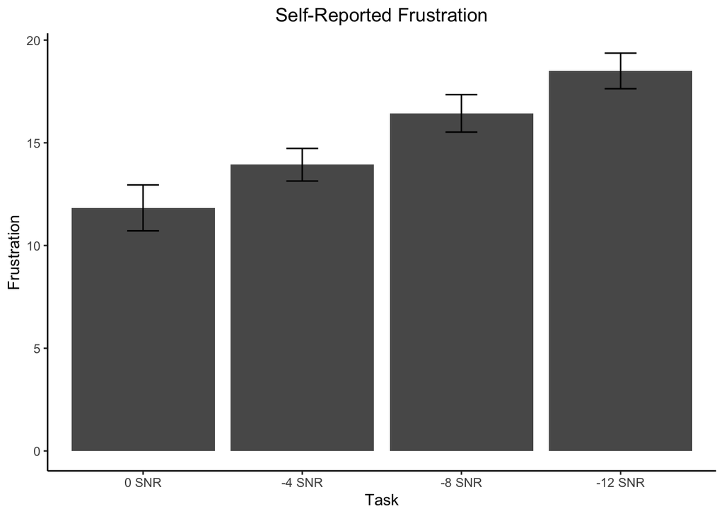

```r
#Frustration Ratings
NASA.frust <- coged %>% select(subjectid, frustration_1, frustration_2, frustration_3, frustration_4) %>%
  group_by(subjectid) %>%
  pivot_longer(names_to = "frustration", values_to = "rating", -c(subjectid)) %>%
  separate(col = frustration, into=c(NA,"Task"), sep = "_")
NASA_frust_sum <- summarySEwithin2(NASA.frust, measurevar = "rating", withinvars = c("Task"), idvar = "subjectid")
NASA_frust_sum$Task <- factor(NASA_frust_sum$Task, levels = c(1,2,3,4), labels = c("0 SNR","-4 SNR","-8 SNR","-12 SNR"))

p.frust <- ggplot(NASA_frust_sum, aes(x=Task, y=rating)) +
  theme(plot.title = element_text(hjust = 0.5), panel.grid.major = element_blank(), panel.grid.minor = element_blank(), panel.background = element_blank(), axis.line = element_line(colour = "black")) +
  geom_bar(stat="identity", position=position_dodge()) +
  geom_errorbar(position=position_dodge(width=0.9), aes(ymin=rating-ci, ymax=rating+ci), width=.2) +
  xlab("Task") + ylab("Frustration") + ggtitle("Self-Reported Frustration")
p.frust
```

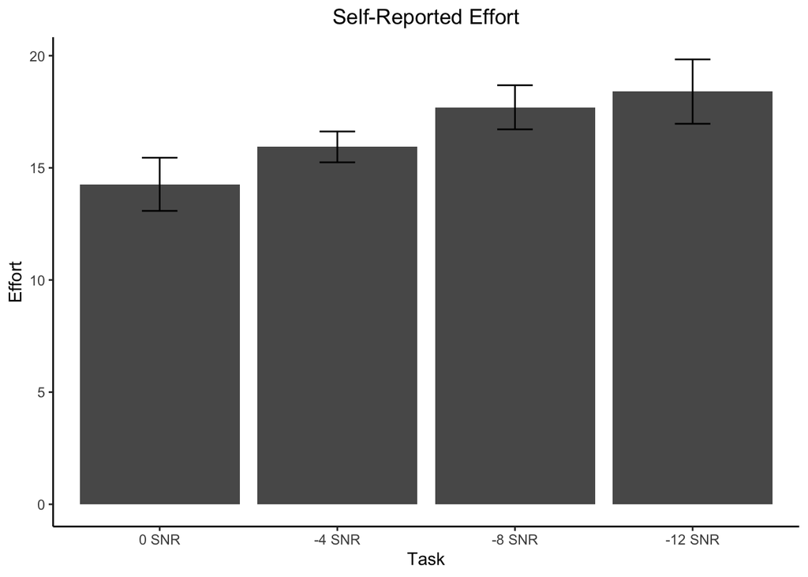

```r
#Effort Ratings
NASA.effort <- coged %>% select(subjectid, effort_1, effort_2, effort_3, effort_4) %>%
  group_by(subjectid) %>%
  pivot_longer(names_to = "effort", values_to = "rating", -c(subjectid)) %>%
  separate(col = effort, into=c(NA,"Task"), sep = "_")
NASA_effort_sum <- summarySEwithin2(NASA.effort, measurevar = "rating", withinvars = c("Task"), idvar = "subjectid")
NASA_effort_sum$Task <- factor(NASA_effort_sum$Task, levels = c(1,2,3,4), labels = c("0 SNR","-4 SNR","-8 SNR","-12 SNR"))

p.effort <- ggplot(NASA_effort_sum, aes(x=Task, y=rating)) +
  theme(plot.title = element_text(hjust = 0.5), panel.grid.major = element_blank(), panel.grid.minor = element_blank(), panel.background = element_blank(), axis.line = element_line(colour = "black")) +
  geom_bar(stat="identity", position=position_dodge()) +
  geom_errorbar(position=position_dodge(width=0.9), aes(ymin=rating-ci, ymax=rating+ci), width=.2) +
  xlab("Task") + ylab("Effort") + ggtitle("Self-Reported Effort")
p.effort
```

## Familiarization Phase Performance

```r
performance <- coged %>% select(subjectid, percentCorrect_N1, percentCorrect_N2, percentCorrect_N3, percentCorrect_N4) %>%
   group_by(subjectid) %>%
  pivot_longer(names_to = "level", values_to = "performance", -c(subjectid)) %>%
  separate(col = level, into=c(NA,"Task"), sep = "_")

performance_sum <- summarySEwithin2(performance, measurevar = "performance", withinvars = c("Task"), idvar = "subjectid")
performance_sum$Task <- factor(performance_sum$Task, levels = c("N1","N2","N3","N4"), labels = c("0 SNR","-4 SNR","-8 SNR","-12 SNR"))

performance.table <- kable(performance_sum %>% select(!contains("Normed")), caption = "Mean Accuracy of Keywords across Load Levels") %>%  kable_styling(bootstrap_options = c("striped", "hover", "condensed"))
performance.table
```

Mean Accuracy of Keywords across Load Levels

| Task | N | performance | sd | se | ci |
| --- | --- | --- | --- | --- | --- |
| 0 SNR | 30 | 61.700000 | 11.238877 | 2.051929 | 4.196666 |
| -4 SNR | 30 | 51.666667 | 9.441192 | 1.723718 | 3.525399 |
| -8 SNR | 30 | 26.500000 | 8.902521 | 1.625371 | 3.324256 |
| -12 SNR | 30 | 8.033333 | 13.631371 | 2.488736 | 5.090038 |

## Post-Task Questionnaire

#### Participants completed post-task ratings at the conclusion of the experiment (likert scale: 1-10)

### Avoidance = To what degree did you choose the easier task because you wanted to avoid difficulty?

### Caring = To what degree did you select tasks based on whether or not you would be able to win (or lose) money?

### Challenge = To what degree did you choose the harder task because you wanted to challenge yourself?

### Difficulty = To what degree were your choices based on the difficulty of each task?

### Effort = To what degree were your choices based on the amount of effort each task required?

### Maintenance = To what degree did you select tasks based on whether or not you would be able to maintain your effort?

### Money = To what degree were your choices based on the offer amount ($) of each task?

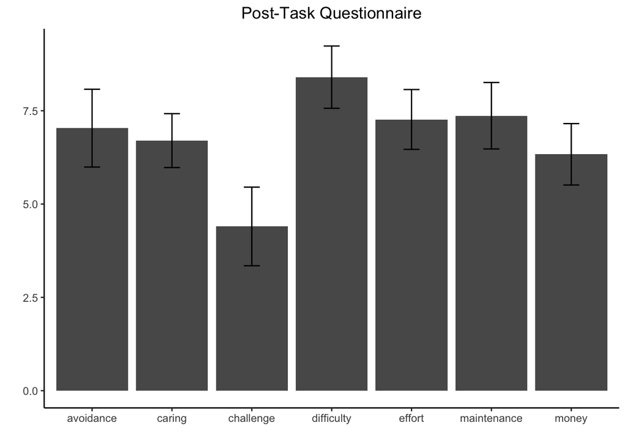

```r
PTQ.clean <- PTQ %>%  select(subject, ends_with("response")) %>% select(!contains("strat")) %>% select(!contains("listening")) %>%
  pivot_longer(names_to = "dimension", values_to = "rating", -subject) %>%
  separate(col = dimension, into=c("dimension",NA), sep = "_")

PTQ_sum <- summarySEwithin2(PTQ.clean, measurevar = "rating", withinvars = c("dimension"), idvar = "subject")

p.PTQ <- ggplot(PTQ_sum, aes(x=dimension, y=rating)) +
  theme(plot.title = element_text(hjust = 0.5), panel.grid.major = element_blank(), panel.grid.minor = element_blank(), panel.background = element_blank(), axis.line = element_line(colour = "black")) +
  geom_bar(stat="identity", position=position_dodge()) +
  geom_errorbar(position=position_dodge(width=0.9), aes(ymin=rating-ci, ymax=rating+ci), width=.2) +
  xlab("") + ylab("") + ggtitle("Post-Task Questionnaire")
p.PTQ
```

### Self-Reported Strategies

```r
#self-reported strategies
PTQ.strat.subset <- PTQ %>% select(contains("strat")) %>% select(!contains("latency"))
kable(PTQ.strat.subset)
```

| hard_strat_gain_response | easy_strat_gain_response |
| --- | --- |
| For the money | To balance the harder task I choosed before |
| I only chose the harder task, if the other option was not appealing. For example if I need to choose between a black task with a offer of 0.07£ (almost nothing) and a purple task with a offer of 2.00£… | I chose the easier task almost everytime because I think that the relation effort/benefit is better and is less frustating than the others. |
| To earn more money. | I didn’t choose easier task. |
| I only chose the harder tasks when the price was much higher than the easier one. | It would be more likely to win the bonus sense it was easier. Let’s say it was a safer choice |
|  | I wasnt able to hear anything on those hareder levels |
| I tried to choose red if it gave more money than black, but always those 2 because I was unable to hear blue and purple. | I tried to choose red if it gave more money than black, but always those 2 because I was unable to hear blue and purple. |
|  | I dont wanted to make me feel uncomfortable. |
|  | I knew I couldn’t win the purple one so I never selected it. |
| I only chose the harder task when the financial reward was a lot higher than the other task or when the difference in difficulty wasn’t that high. For example, I chose the purple task when its reward … | I chose the easier task when the difference in the reward was very low and neither of the tasks were the hardest one. For example, I chose the black task instead of the blue task when the difference b… |
| i want to improve my english | for some easy examples |
| Did not choose harder task | Chose easier task because .. it was easier. |
| If i could get way more money | if there won’t be much less money to get |
|  | becouse i knew for harder i couldnt finish since heard barely one word when easy i could hear more and theres no proof ll earn more than easier one |
| Because of the monetary compensation. | The monetary compensation compared to the effort needed was way better than the other options. |
| t was easier to maintain my efforts. allows me to challenge myself. | less effort. less stress |
|  | for a higher success rate |
|  | Because during first round of tasks it was so hard for me to hear sentences because of noise. |
| at most I chose it because the other choice gave me only a very few cents (and so it didn’t worth it) | because I knew that I have more possibilities in performing good! As it happens for the black level |
| if the monetary difference was wider by a lot, and the option wasn’t harder by a lot | I almost always chose the easier task as the others were too difficult and I would likely win no money at all |
| i wanted challenge myself | to stay chill jaja |
| i chose it easier | why is it easier |
| I chose purple instead of black when the reward on purple was at leats 3 times the reward on black | I chose the easier taks whwn the reward wasn’t much lower than the reward on the hardest. Chose black instead of red whenrewad of black was 1.44 and of red 2 |
| I didn’t i want to able to hear almost anything in the last two phases | Because the purple and the red section were so hard i barely heard any words. |
| Mainly because it was more money |  |
| as the money reward was larger | as i was odds on to get them more correct |
| the amount of money between the task | base on the difficulti level I rather choose the easier one |
| because the amount of the reward was a lot more than the other task | because I wanted to be sure that I could do well |
| Because it had a better reward but I only stayed at red and black. |  |